# Lecture 2: PY 0782 - Advanced Quantitative Research Methods

2018-09-06 | disclaimer

## PY0782: Advanced Quantitative research methods.

- Last week: Introduction.
- Today all about visualization.

## Goals (today)

Data manipulation.

Data visualization.

Basic tests (*t*-tests, and a non-parametric alternative.)

## Assignment

After today you should be able to complete the following sections:

Descriptive statistics and data wrangling.

Histogram

Violin plot

*t*-test and non-parametric alternative

## Flights dataset

Again this is based on [Whickham & Grolemund (2017)](http://r4ds.had.co.nz/) and on work by [Gert Stulp](http://www.gertstulp.com/)

```r
setwd("~/Dropbox/Teaching_MRes_Northumbria/Lecture2")
library(nycflights13)
flights<-nycflights13::flights
```

## 'dplyr'

**Last week:** Pick observations by their values: **filter()**.

Reorder the rows: **arrange()**. (read about this [here](http://r4ds.had.co.nz/transform.html#arrange-rows-with-arrange))

*Pick variables by their names **select()**.*

*Create new variables with functions of existing variables **mutate()**.*

*Collapse many values down to a single summary **summarise()**.*

## Load dplyr

Load dplyr:

```r
library(dplyr)
```

## select()

Sometimes you have dozens, even >100 or >1000 variables.

You can use select() to make a reduced data frame.

```r
flights_red<-select(flights, year, month, day)
###This overrides our earlier attempt
flights_red<-select(flights, year:day)
### all columns excluding those from year:day (inclusive)
flights_red<-select(flights, -(year:day))
```

## Try it yourself.

Team up with a partner.

Load the flights data.

Make a new dataframe with all variables starting from dep_time to arr_delay (inclusive).

## helper functions.

For more complex cases:

starts_with("abc"): matches names that begin with “abc”.

ends_with("xyz"): matches names that end with “xyz”.

contains("ijk"): matches names that contain “ijk”.

matches("(.)\1"): selects variables that match a "regular expression". This one matches any variables that contain repeated characters. ??regex

num_range("x", 1:3): matches x1, x2 and x3.

## rename()

- select() can be used to rename variables, **but** it drops all of the variables not explicitly mentioned.
- Instead, use rename(), which is a variant of select() which keeps all the variables that are not explicitly mentioned.
- However, I found this to be [buggy](https://stackoverflow.com/questions/34275576/avoiding-error-when-using-rename-in-dplyr-and-column-doesnt-exist) so back to base R but feel free to use rename().

## names

```r
# Note the square brackets for indexing the columns.
names(flights_red)[1:3]=c("Year", "Month", "Day")
head(flights_red)
```

```
## # A tibble: 6 x 16
##    Year Month   Day arr_time sched_arr_time arr_delay carrier flight
##   <int> <int> <dbl>    <int>          <int>     <dbl> <chr>    <int>
## 1   517   515     2      830            819        11 UA        1545
## 2   533   529     4      850            830        20 UA        1714
## 3   542   540     2      923            850        33 AA        1141
## 4   544   545    -1     1004           1022       -18 B6         725
## 5   554   600    -6      812            837       -25 DL         461
## 6   554   558    -4      740            728        12 UA        1696
## # ... with 8 more variables: tailnum <chr>, origin <chr>, dest <chr>,
## #   air_time <dbl>, distance <dbl>, hour <dbl>, minute <dbl>,
## #   time_hour <dttm>
```

## mutate()

%>% : the pipe. Basically means apply function to.

mutate() allows you to make new variables

```r
flights <- flights %>% mutate(speed = distance / (air_time * 60), log_speed=log(speed))
```

transmute() if you want **only** the things you have calculated.

## helper functions() for mutate()

Again a whole load of helper functions exist. You can read more about them [here](http://r4ds.had.co.nz/transform.html#add-new-variables-with-mutate)

the key thing to remember is that you can apply all the functions we covered last week.

## Centering and standardizing.

**centering**: subtracting the mean. (Often used to make scores more interpretable and to avoid collinearity, which is a big [deal](https://link.springer.com/article/10.1007/s00265-010-1045-6)). More about this when we discuss OLS regression.

**standardizing**: Z-scores. We use the scale() function.

```r
flights<- flights %>% mutate(speed_cent = speed - mean(speed, na.rm = TRUE))
flights<- flights %>% mutate(speed_stand = scale(speed))
```

- now about that 'na.rm = TRUE' –> this removes any missings.
- Reminder about Z-scores.

[figure not shown]

## summarise()

Get one row with data for the dataframe.

```r
summarise(flights, mean_speed = mean(speed, na.rm = TRUE))
```

```
## # A tibble: 1 x 1
##   mean_speed
##        <dbl>
## 1      0.110
```

## group_by

more useful if combined with group_by , let's look at delays by [carrier](http://aspmhelp.faa.gov/index.php/ASQP:_Carrier_Codes_and_Names)

```r
by_carrier <- group_by(flights, carrier)
summarise(by_carrier, delay = mean(dep_delay, na.rm = TRUE))
```

```
## # A tibble: 16 x 2
##    carrier delay
##    <chr>   <dbl>
##  1 9E      16.7
##  2 AA       8.59
##  3 AS       5.80
##  4 B6      13.0
##  5 DL       9.26
##  6 EV      20.0
##  7 F9      20.2
##  8 FL      18.7
##  9 HA       4.90
## 10 MQ      10.6
## 11 OO      12.6
## 12 UA      12.1
## 13 US       3.78
## 14 VX      12.9
## 15 WN      17.7
## 16 YV      19.0
```

## Try it yourself.

- calculate 'gain' which is arr_delay - dep_delay.
- calculate 'airtime_hours' which is airtime (in mins.) divide by the number of minutes in an hour.
- now calculate 'gain per hour'. (gain/airtime_hours)
- standardize 'gain per hour'.
- use group_by to calculate the means of gain per hour by carrier.

## Replacing missings.

Often we want to replace missings. For example, we want to replace the missings with the means or median.

```r
flights <- flights %>% mutate(dep_delay_no_miss= ifelse(is.na(dep_delay),
           mean(dep_delay, na.rm = T), dep_delay))
mean(flights$dep_delay_no_miss)
```

```
## [1] 12.63907
```

Here we use an 'ifelse' function to replace the missings.

True can be abbreviated to 'T'.

## So far, so good.

Now that we know the basics of manipulating dataframes let's move to graphs.

Why is plotting your data important?

[Anscombe's quartet (1973)](http://www.jstor.org/stable/pdf/2682899.pdf?refreqid=excelsior%3A19d1f2fcfb1dacfb0ec692faa1512a37). *r*= .816

[figure not shown]

Often: testing important assumptions.

## Datasaurus.

- An extension of Anscombe's quartet. Read more [here](https://www.autodeskresearch.com/publications/samestats)

[figure not shown]

## Now let's make some graphs.

ggplot2

some 'helper' packages, 'scales' helps with axes, 'Rcolorbrewer' use, 'ggthemes' allows standardized templates, 'cow plot' allows panelling graphs.

```r
library(ggplot2)
library(scales) ### no longer needed in newer versions.
library(RColorBrewer)
library(ggthemes)
```

## Scatter plot

- Our data file is truly massive, so for this exercise we are just going to select all flights from JFK airport on christmas day.

```r
flights_jfk_new<-filter(flights, month == 12, day == 25, origin == 'JFK')
```

- Scatter plot

```
## Warning: Removed 2 rows containing missing values (geom_point).
```

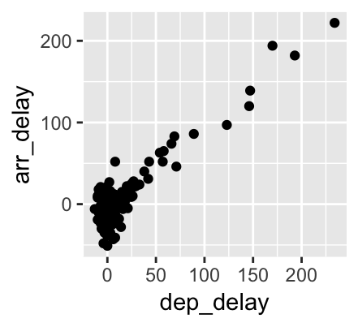

```r
ggplot(flights_jfk_new, aes(x=dep_delay, y=arr_delay)) + geom_point()
```

## What is that warning about?

- 2 missing cases.
- Let us replace those, in fact we already did that for dep_delay, but that was based on the **whole** set. For this exercise, we'll replace it again (so now it is replaced with the mean on X-mas day)

```r
flights_jfk_new <- flights_jfk_new %>%
                   mutate(dep_delay_no_miss= ifelse(is.na(dep_delay),
                   mean(dep_delay, na.rm = T), dep_delay))
flights_jfk_new <- flights_jfk_new %>%
                   mutate(arr_delay_no_miss= ifelse(is.na(arr_delay),
                   mean(arr_delay, na.rm = T), arr_delay))
```

## Plot again

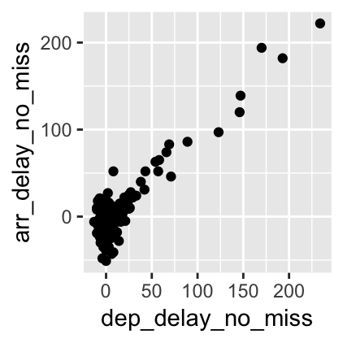

```r
graph_delays<-ggplot(flights_jfk_new, aes(x=dep_delay_no_miss, y=arr_delay_no_miss))
graph_delays + geom_point()
```

## Colour by airline

Recap: ggplot(your_data, aes(x=x_variable, y=y_variable)) + geom_point()

Now let's colour it by carrier.

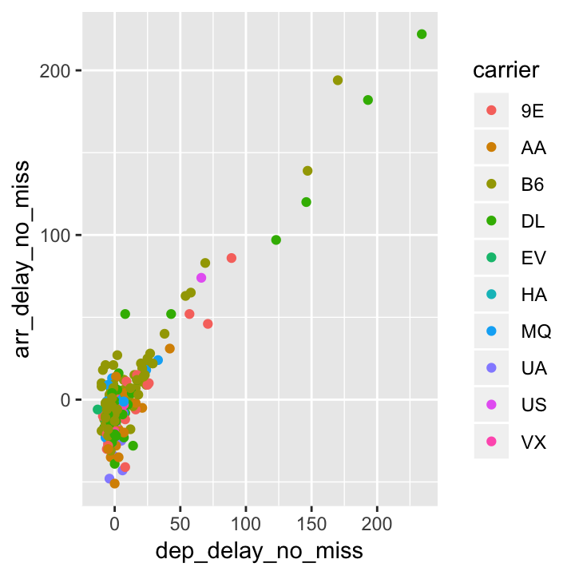

```r
graph_colour <- ggplot(flights_jfk_new, aes(x=dep_delay_no_miss, y=arr_delay_no_miss,
                                             colour=carrier))
graph_colour + geom_point()
```

## Flexibility.

- The beauty of ggplot is that using a different “geom”-function will create a different graph:

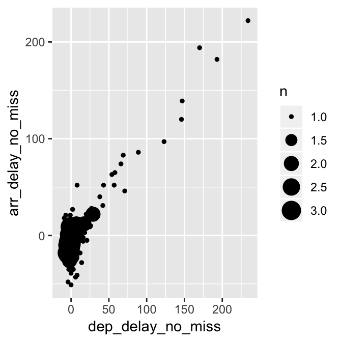

```r
graph_delays + geom_count()
```

## Let's try another one.

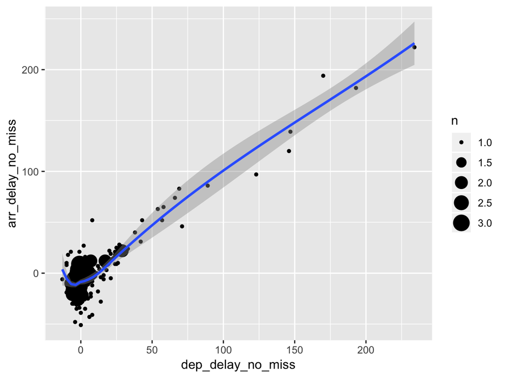

```r
graph_delays +  geom_count() + geom_smooth()
```

## Try it yourself.

- Make a similar set as we did but now: flights leaving LaGuardia (LGA) airport on X-mas day.
- Make a plot with departure delay on the X-axis and speed on the Y-axis.
- Colour the points by carrier.

[figure not shown]

## You can tweak everything!

Example with Delta and United airlines.

```r
flights_jfk_new_2_airlines<-filter(flights_jfk_new, carrier== "DL" | carrier== "UA" )
graph_beauty<-ggplot(flights_jfk_new_2_airlines,
                     aes(x=dep_delay_no_miss, y=arr_delay_no_miss,
                                             colour=carrier))  +
  geom_point(size=3, shape=13, alpha=0.5) + ### size/shape of points + transparency
  geom_smooth(method="lm") + ### Add linear regression lines
  scale_colour_brewer(palette = "Set1") + # Change the colours
  labs(x="Delay departure", y="Delay arrival",
       title="United vs. Delta - Showdown") +
  # Change labels on axes and add title
  theme_bw() # Remove the gray background
```

## Look at the pretty, pretty!

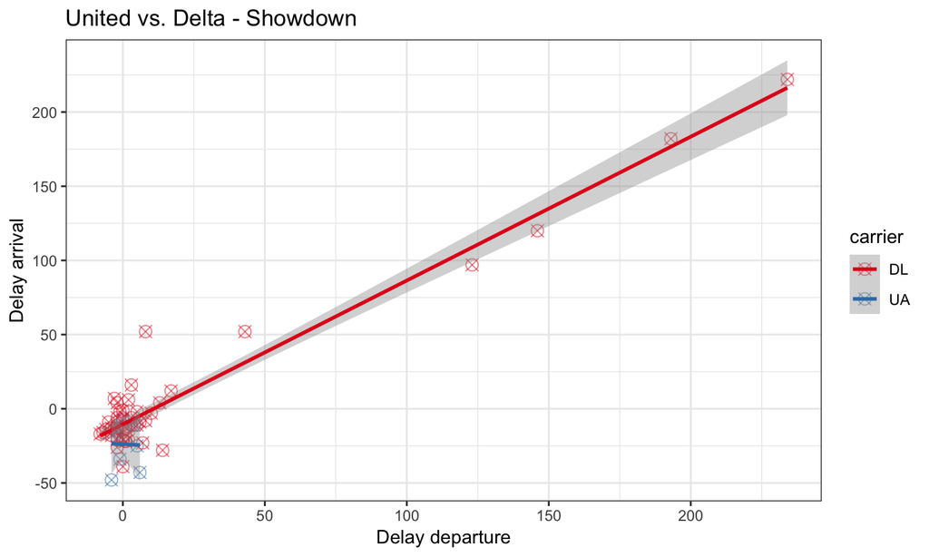

```r
graph_beauty
```

## Many types of graphs.

| # | geom | graph |
| --- | --- | --- |
| 1 | geom_density() | Density plot (distribution) |
| 2 | geom_histogram() | Histogram (distribution) |
| 3 | geom_violin() | Violin pot (multiple distributions) |
| 4 | geom_boxplot() | Boxplot (multiple distributions) |
| 5 | geom_bar() | Bar chart (categorical + continuous/categorical) |
| 6 | geom_point() | Scatter (continuous + continuous) |
| 7 | geom_count() | Bubble plot (continuous + continuous/categorical) |
| 8 | geom_jitter() | Scatter (continuous + continuous/categorical) |

## Many types of graphs, continued

| # | geom | graph |
| --- | --- | --- |
| 9 | geom_smooth() | Prediction line (continuous + continuous) |
| 10 | geom_line() | Line (continuous + continuous/categorical) |
| 11 | geom_errorbar() | Errorbar (continuous + continuous/categorical) |

We will not cover all of these today.

Need any help / reference? All the codes can be found [here](http://ggplot2.tidyverse.org/reference/)

## Histogram.

Let's make a panelled histogram comparing the delays in departure of two major airlines Jetblue (code= B6) and Delta airlines on X-mas day.

To help ourselves we'll make to separate sets. We'll also save them.

```r
###Note that I now went for new, short names.
###Ideally you want your naming to be consistent.
jfk_delta<-filter(flights_jfk_new, carrier== "DL")
jfk_jetblue<-filter(flights_jfk_new, carrier== "B6")
write.csv(jfk_delta,row.names = F, file= 'jfk_delta.csv')
write.csv(jfk_jetblue,row.names = F, file= 'jfk_jetblue.csv')
```

## Basics.

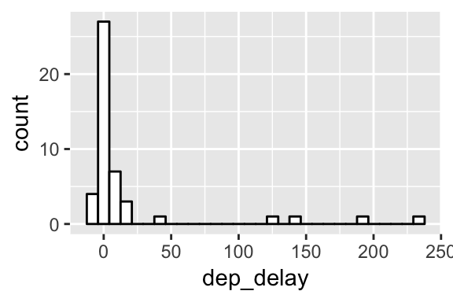

```r
plot_dl<-ggplot(jfk_delta, aes(dep_delay))
plot_jetblue<-ggplot(jfk_jetblue, aes(dep_delay))
### Plot Delta.
plot_dl+geom_histogram(colour = "black", fill = "white")
```

## Binwidth?

- Defaults used. Binwidth is [important](http://www.stat.cmu.edu/~rnugent/PCMI2016/papers/WandBinWidth.pdf). Not too large/small.

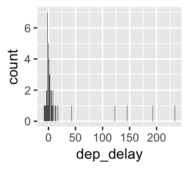

```r
plot_dl+geom_histogram(binwidth=1)
```

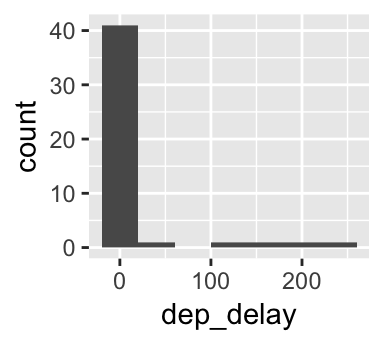

```r
plot_dl+geom_histogram(binwidth=40)
```

## Settle on 5?

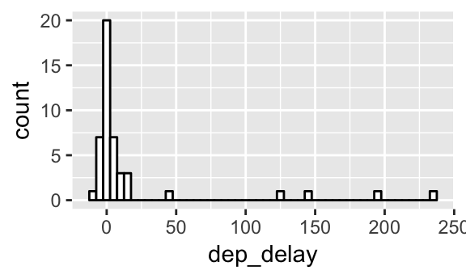

```r
plot_dl<-plot_dl+geom_histogram(binwidth=5, colour = "black", fill = "white")
plot_jetblue<-plot_jetblue + geom_histogram(binwidth=5, colour = "black", fill = "white")
plot_dl
```

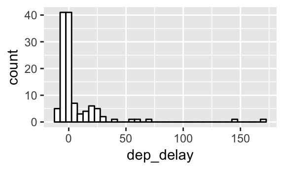

```r
plot_jetblue
```

## Change labels.

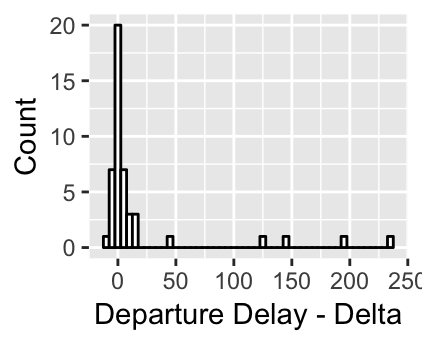

```r
plot_dl+ylab("Count") + xlab("Departure Delay - Delta")
```

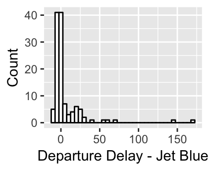

```r
plot_jetblue + ylab("Count") + xlab("Departure Delay - Jet Blue")
```

## Change the ticks / axes limits.

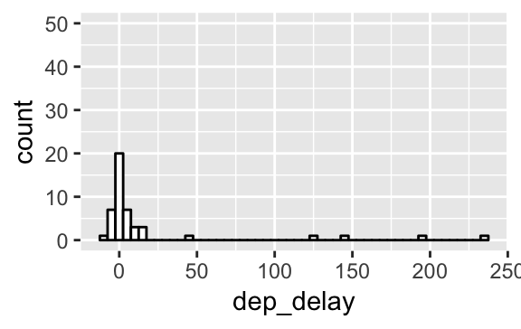

```r
plot_dl+ scale_y_continuous(limits=c(0,50),breaks = pretty_breaks(6))
```

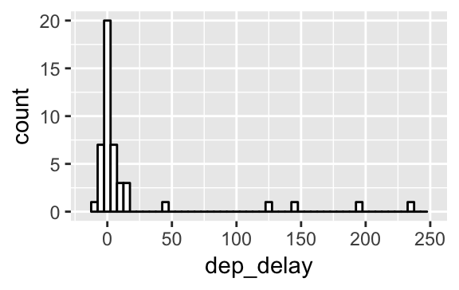

```r
plot_dl+ scale_x_continuous(limits=c(-15,250),breaks = pretty_breaks(6))
```

## Intermediate formatting lost.

- In the end we will need *all* the commands in one go! Or we need to store intermediate graphs and update those!

## Themes.

- ggthemes. ??ggthemes for all options.
- google doc theme. Base size = fonts.

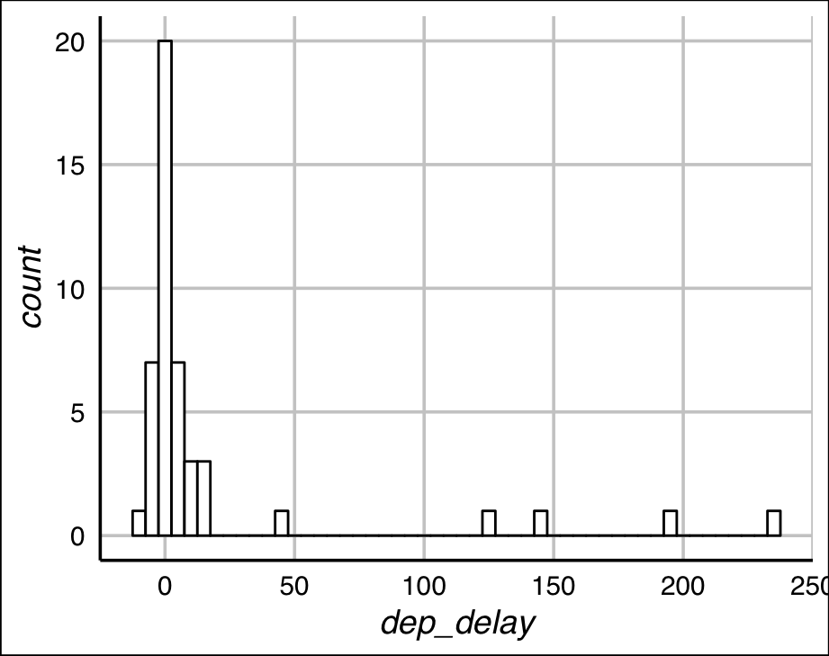

```r
plot_dl+theme_gdocs(base_size = 14)
```

## All in one!

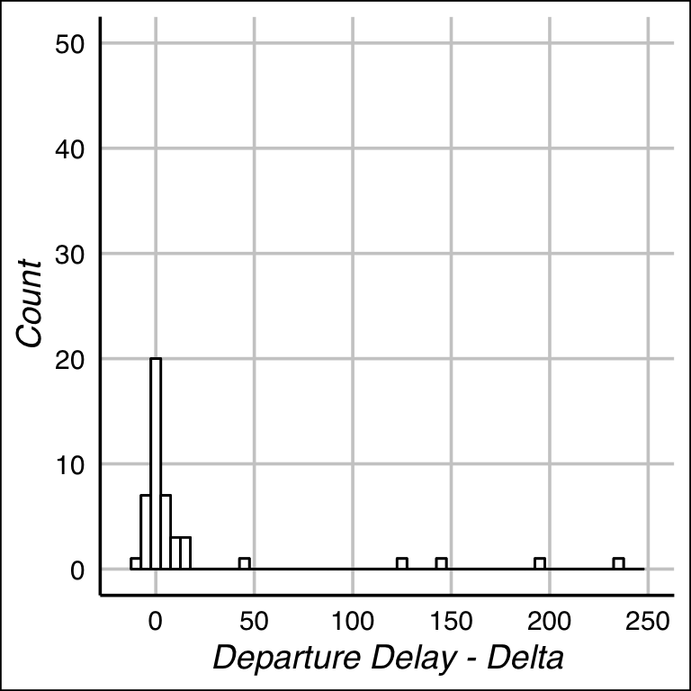

```r
plot_dl <- plot_dl + geom_histogram(binwidth = 5, colour = "black",
    fill = "white") + ylab("Count") + xlab("Departure Delay - Delta") +
    scale_y_continuous(limits = c(0, 50), breaks = pretty_breaks(6)) +
    scale_x_continuous(limits = c(-15, 250), breaks = pretty_breaks(6)) +
    theme_gdocs(base_size = 14)
plot_dl
```

## Try it yourself.

- Make a plot for jetblue, similar to the one for Delta Airlines
- Solution

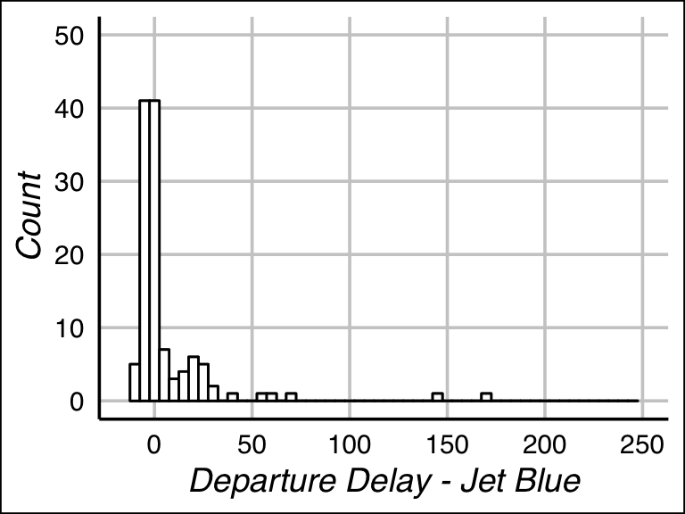

```r
plot_jetblue <- plot_jetblue + geom_histogram(binwidth = 5,
    colour = "black", fill = "white") + ylab("Count") +
    xlab("Departure Delay - Jet Blue") + scale_y_continuous(limits = c(0,
    50), breaks = pretty_breaks(6)) + scale_x_continuous(limits = c(-15,
    250), breaks = pretty_breaks(6)) + theme_gdocs(base_size = 14)
plot_jetblue
```

## Saving it. ggsave??

```r
ggsave("plot_jetblue.pdf", width = 250, height = 250, units = "mm")
```

default is to save last plot displayed but you can explicitly name it (plot = )

You can change the output size to different units ("in")

dpi for resolution.

different formats (e.g., .png, .tiff)

It will be saved in your working directory. (change that with path = ).

## Combing multiple charts. plot_grid()

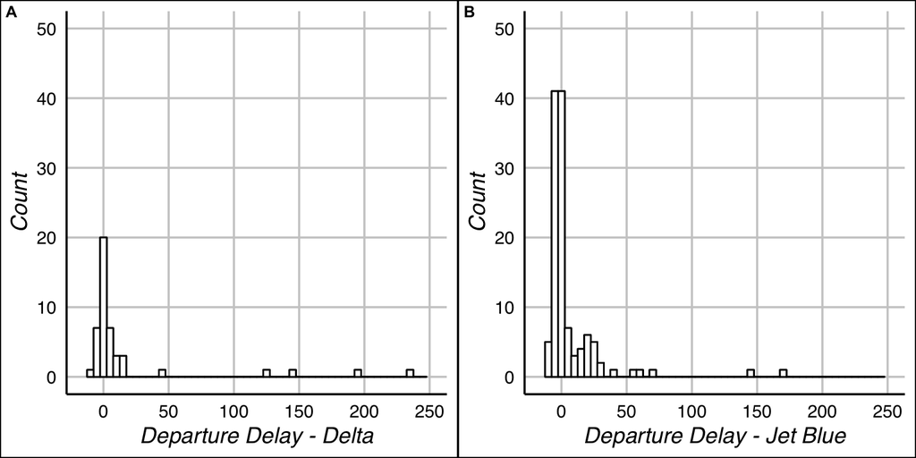

```r
library(cowplot)
plot_grid(plot_dl, plot_jetblue, labels = c("A", "B"), label_size = 10,
    align = "h")
```

```r
ggsave("plot_panelled.pdf", width = 250, height = 250, units = "mm")
```

## Interpretation.

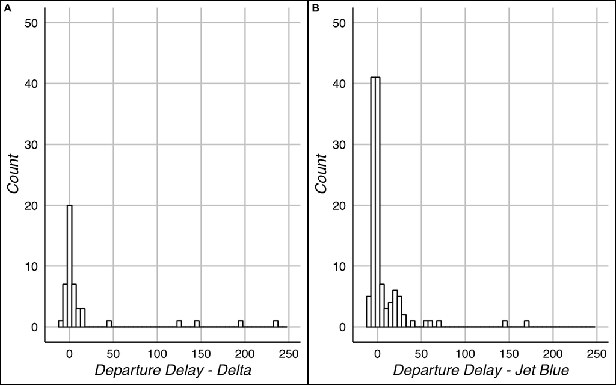

## What is good/bad about this chart?

- Quite clear.
- Only 2 groups? Overlay?
- Varying N. Sample size.
- White space.
- Units? (in minutes).

## Violin plot (with box plot)

- Now let's approach this in a different way.
- Violin plots combined with a box plot (remember last week) give us good overview.

## Basic violin plot.

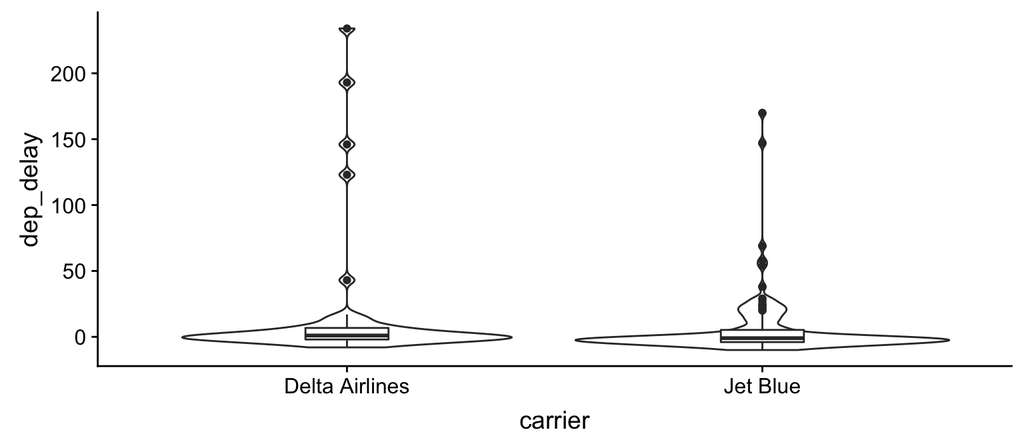

```r
### combine them into a single dataframe.
violinplot_data <- rbind.data.frame(jfk_delta, jfk_jetblue)
library(dplyr)
violinplot_data <- violinplot_data %>% mutate(carrier = recode(carrier,
    B6 = "Jet Blue", DL = "Delta Airlines"))
### make plot
violinplot <- ggplot(violinplot_data, aes(x = carrier,
    y = dep_delay)) + geom_violin() + geom_boxplot(width = 0.2)
violinplot
```

## Add some 'oomph'.

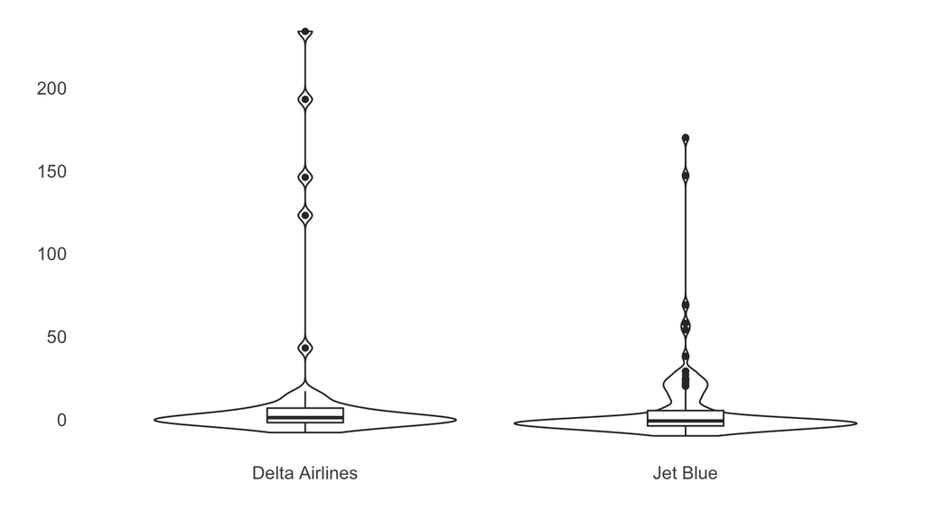

```r
violinplot + xlab("Carrier") + ylab("Delay Departure (mins.)") +
    theme_few(14)
```

## Can you describe the graph?

- What are the key points?

## Changing the order.

- Suppose we want Jet Blue on the left for the X-axis.

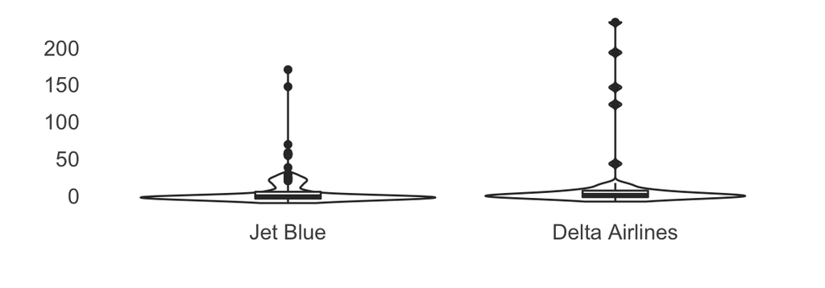

```r
### recode.
library(haven)  # needed for as_factor
violinplot_data$carrier_rec <- as_factor(violinplot_data$carrier)
ordered_levels <- c("Jet Blue", "Delta Airlines")
violinplot_data <- mutate(violinplot_data, carrier_rec = factor(carrier_rec,
    levels = ordered_levels))
### violinplot_2
violinplot_2 <- ggplot(violinplot_data, aes(x = carrier_rec,
    y = dep_delay)) + geom_violin() + geom_boxplot(width = 0.2) +
    xlab("Carrier") + ylab("Delay Departure (mins.)") +
    theme_few(14)
violinplot_2
```

## *t*-test: Are there more delays with Delta than with Jet Blue?

- Let's run an independent samples *t*-test

```r
t.test(dep_delay~carrier, data=violinplot_data)
```

```
##
##  Welch Two Sample t-test
##
## data:  dep_delay by carrier
## t = 1.4522, df = 52.832, p-value = 0.1524
## alternative hypothesis: true difference in means is not equal to 0
## 95 percent confidence interval:
##  -4.351906 27.177268
## sample estimates:
## mean in group Delta Airlines       mean in group Jet Blue
##                    17.304348                     5.891667
```

## Let's break it down.

- dependent variable~independent variable
- Welch correction, this corrects for assumption of equality of variances. And should be the [default](https://www.rips-irsp.com/articles/10.5334/irsp.82/galley/42/download/), also check [this](https://academic.oup.com/beheco/article/17/4/688/215960/The-unequal-variance-t-test-is-an-underused).

## No SD?

- We need standard deviations for our report!

```r
sd(jfk_delta$dep_delay_no_miss)
```

```
## [1] 51.17242
```

```r
sd(jfk_jetblue$dep_delay_no_miss)
```

```
## [1] 24.09847
```

## APA style write up.

You have done this before!

An independent-samples *t*-test was used to compare the delays in departure between Delta Airlines and Jet Blue in minutes. There was no significant difference between Delta airlines (*M* = 17.30, *SD* = 51.17) and Jet Blue (*M* = 5.89, *SD*= 24.10) in average departure delay time, *t*(52.83)= 1.45, *p*=.15.

## Non-parametric tests.

- Do not make typical assumptions associated with parametric statistics (e.g., (roughly) normal distribution).
- Useful in our case, given the clear extreme values!
- Downside: information lost, often less powerful.

## Wilcoxon-Mann-Whitney U.

- Other alternatives exist (e.g., Mood's median test)
- Wilcoxon-Mann-Whitney U is common [alternative](http://vassarstats.net/textbook/ch11a.html) to _t_test. (Sometimes, just called Mann-Whitney U).

```r
wilcox.test(dep_delay~carrier, data=violinplot_data)
```

```
##
##  Wilcoxon rank sum test with continuity correction
##
## data:  dep_delay by carrier
## W = 3375.5, p-value = 0.02619
## alternative hypothesis: true location shift is not equal to 0
```

## Kruskal-Wallis.

- We need as_factor. Read more [here](http://vassarstats.net/textbook/ch14a.html)

```r
kruskal.test(dep_delay~as_factor(carrier), data=violinplot_data)
```

```
##
##  Kruskal-Wallis rank sum test
##
## data:  dep_delay by as_factor(carrier)
## Kruskal-Wallis chi-squared = 4.9518, df = 1, p-value = 0.02606
```

## Medians?

- We need the medians for our report!

```r
median(jfk_delta$dep_delay_no_miss)
```

```
## [1] 1
```

```r
median(jfk_jetblue$dep_delay_no_miss)
```

```
## [1] -1
```

## APA style write up.

- A Wilcoxon-Mann-Whitney test showed that there was a significant difference between Delta airlines (*Mdn* = 1) and Jet Blue (*Mdn*= -1) in delays, *W*= 3375.5, *p*= .026.
- So: Delta airlines significantly later than Jet Blue.

## Bootstrapping!

Bootstrapping is sampling *with replacement*

It is a non-parametric technique.

Basically repeatedly drawing a sample and calculating a statistic.

Can be applied to nearly any technique.

## How to do it.

boot package. Find out more [here](http://people.tamu.edu/~alawing/materials/ESSM689/Btutorial.pdf).

We make a function with two arguments (data and indices). We will then feed our data to the function!

```r
### Bootstrap 95% CI for t-test
library(boot)
# @@ function to obtain p.values from t.test
# from the data
p_value <- function(data, indices) {
    data_boot <- data[indices, ]  # allows boot to select sample
    T_test_boot <- t.test(dep_delay ~ carrier,
        data = data_boot)
    return(T_test_boot[[3]])  ### [[]] denotes the position in output - 3rd element
}
```

## Now let's run it.

```r
### Bootstrapping is truly random.  We need a 'seed' to
### make it replicable.
set.seed(2017)
### R is number of samples we want to draw?  we store it
### in results.
results <- boot(data = violinplot_data, statistic = p_value,
    R = 10000)
```

## Results.

```r
## view results
head(results)
```

[output not shown]

[output cut: 10151 more lines]

## Plot Results.

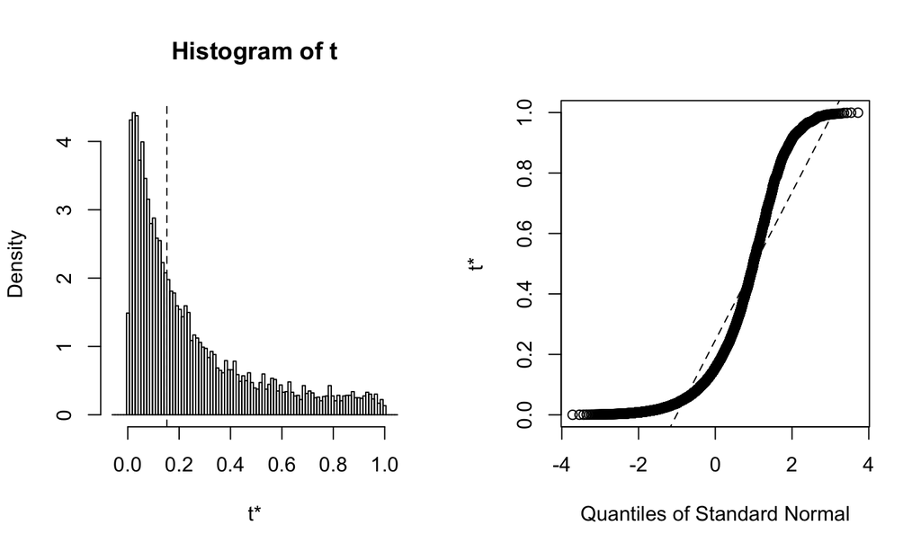

```r
plot(results)
```

## 95%CI for *p*.

- Various types. Read all about [here](http://www.tau.ac.il/~saharon/Boot/10.1.1.133.8405.pdf)
- One of the ['best'](https://faculty.washington.edu/heagerty/Courses/b572/public/GregImholte-1.pdf) methods is Bias-Corrected Accelerated.

```r
boot.ci(results, type="bca")
```

```
## BOOTSTRAP CONFIDENCE INTERVAL CALCULATIONS
## Based on 10000 bootstrap replicates
##
## CALL :
## boot.ci(boot.out = results, type = "bca")
##
## Intervals :
## Level       BCa
## 95%   ( 0.0059,  0.8575 )
## Calculations and Intervals on Original Scale
```

## What would you write in your report?

- The 95% Bias-Corrected Accelerated interval (using 10,000 bootstrap samples) for *p* was [.006, .858].

## Test it yourself.

- Do the same as shown but now do it for delay in arrival.

## Exercise.

- Install and load the 'carData' package. load the professorial 'Salaries' dataset.
- This dataset has 397 cases and 6 variables. ??Salaries. Have a look (perhaps use ??skimr)
- Calculate the monthly salary (note that these are 9 month salaries)
- Make a 'beautiful' scatter plot with yrs.since.phd on X-axis and monthly salary and save it.
- Colour the scatter plot by gender.
- Make a panelled 'beautiful' histogram with the distribution of salaries by rank and save it.

## Exercise (cont'd).

- Make a 'beautiful' violin plot with gender on the X-axis and monthly salary on Y-axis.
- Test whether men earn more than women do. Use a parametric test and bootstrap it. Also use a non-parametric test. Report it as you would in an academic paper. Reflect and discuss: Why is this a good/bad testing approach?
- Bonus: calculate the mode of monthly income for each gender. calculate the (parametric) 95%CI for the mean of monthly income for each gender.

## References (and further reading.)

- Crawley, M. J. (2013). *The R book: Second edition.* New York, NY: John Wiley & Sons.
- Davison, A. C., & Hinkley, D. V. (1997). *Bootstrap methods and their application*. Cambridge, UK: Cambridge University Press.
- Pruim, R., Kaplan, D., & Horton, N. (2012). [mosaic: project MOSAIC statistics and mathematics teaching utilities](https://cran.r-project.org/doc/contrib/Horton+Pruim+Kaplan_MOSAIC-StudentGuide.pdf). R package version 0.6-2.
- Siegel, S. & Castellan, N.J. Jr. (1988). *Nonparametric statistics for the behavioral sciences. 2nd Edn.* McGraw-Hill, New York.
- Stulp, G. (2017). *ggplotgui*
- Wickham, H., & Grolemund, G. (2017). *[R for data science](http://r4ds.had.co.nz/)*. Sebastopol, CA: O’Reilly.
- Willems, K. (2015) *[How to Make a Histogram with ggplot2](https://www.datacamp.com/community/tutorials/make-histogram-ggplot2#gs.MSjGyL8)*

## Acknowledgments.

[Gert Stulp](http://gertstulp.github.io) provided code for the ggplot2 section of this lecture.